# pi1 Enrichment Report

Darren Cameron

2026-01-28

## eQTL replication pipeline steps

1. `dwnld_obrien`: Download O’Brien 2018 bulk dev-brain eQTL files PMID:30419947
2. `dwnld_bryois`: Download Bryois 2022 sc-adult-brain eQTL files PMID:35915177
3. `dwnld_ziffra`: Download Ziffra 2021 snATAC-seq peaks files PMID:34616060
4. `dwnld_wen`: Download Wen 2024 bulk dev-brain eQTL files PMID:38781368
5. `snp_lookup`: Generate snp lookup for eQTL / ATAC-seq peak enrichments
6. `atac_enrich`: Test for eQTL enrichments in Ziffra ATAC-seq peaks
7. `snp_lookup_indep`: Generate snp lookup for eQTL / ATAC-seq peak enrichments (independent)
8. `atac_enrich_indep`: Test for eQTL enrichments in Ziffra ATAC-seq peaks (independent)
9. `cat_nom_qtl`: Combine per-chr nominal eQTL parquet files into gzip file for pi1 enrichment
10. `pi1_enrich_obrien`: Calc. pi1 enrichments between sn-eQTL and O’Brien 2018 bulk brain eQTL
11. `pi1_enrich_wen`: Calc. pi1 enrichments between sn-eQTL and Wen 2024 bulk brain eQTL
12. `pi1_enrich_bryois`: Calc. pi1 enrichments between sn-eQTL and Bryois 2022 adult brain sn-eQTL
13. `pi1_enrich_fugita`: Calc. pi1 enrichments between sn-eQTL and Fugita 2024 adult brain sn-eQTL
14. `beta_corre`
15. `pi1_enrichments_report`: Rule to create this report

Settings:

- Expression PC: 40 (see tensorQTL_report.html)
- Genotype PCs: 4 (see genotyping_post_impute_report.html)
- Norm methods: quantile

Test direction:

### Ziffra

#### Primary

Table 1. Primary sc-eQTL Enrichment in Ziffra et. al. (2021) snATAC-seq OCRs

Observed vs Permuted Overlap

| eQTL Cell Type | Peak Cell Type | P Value | Observed Overlap | Mean Permuted Overlap | Fold Enrichment |
| --- | --- | --- | --- | --- | --- |
| Glu-UL | ulEN | 0.001 | 267 | 83.0 | 3.220 |
| Glu-UL-0 | ulEN | 0.001 | 129 | 39.2 | 3.290 |
| Glu-UL-1 | ulEN | 0.001 | 75 | 21.3 | 3.520 |
| Glu-UL-2 | ulEN | 0.001 | 111 | 35.4 | 3.140 |
| Glu-DL | dlEN | 0.001 | 159 | 44.3 | 3.590 |
| Glu-DL-0 | dlEN | 0.001 | 67 | 14.1 | 4.760 |
| Glu-DL-1 | dlEN | 0.001 | 42 | 10.3 | 4.070 |
| Glu-DL-2 | dlEN | 0.001 | 44 | 12.8 | 3.450 |
| NPC | RG | 0.001 | 127 | 37.4 | 3.390 |
| NPC-0 | RG | 0.001 | 39 | 8.9 | 4.400 |
| NPC-1 | RG | 0.001 | 62 | 15.3 | 4.060 |
| NPC-2 | RG | 0.001 | 22 | 4.7 | 4.720 |
| GABA | IN_CGE | 0.001 | 139 | 45.7 | 3.040 |
| GABA | IN_MGE | 0.001 | 135 | 43.5 | 3.110 |
| GABA-0 | IN_CGE | 0.001 | 50 | 13.8 | 3.620 |
| GABA-0 | IN_MGE | 0.001 | 48 | 13.3 | 3.610 |
| GABA-1 | IN_CGE | 0.001 | 76 | 22.0 | 3.450 |
| GABA-1 | IN_MGE | 0.001 | 76 | 21.0 | 3.620 |
| GABA-2 | IN_CGE | 0.001 | 13 | 3.7 | 3.560 |
| GABA-2 | IN_MGE | 0.001 | 13 | 3.5 | 3.730 |
| Endo-Peri | EndoMural | 0.001 | 12 | 1.8 | 6.510 |
| OPC | AstroOligo | 0.001 | 15 | 3.6 | 4.140 |
| MG | Microglia | 0.001 | 7 | 1.3 | 5.380 |

#### Secondary

Table 2. Secondary sc-eQTL Enrichment in Ziffra et. al. (2021) snATAC-seq OCRs

Observed vs Permuted Overlap (only cell types with ≥20 secondary eQTLs)

| eQTL Cell Type | Peak Cell Type | P Value | Observed Overlap | Mean Permuted Overlap | Fold Enrichment |
| --- | --- | --- | --- | --- | --- |
| Glu-UL | ulEN | 0.014 | 11 | 4.9 | 2.260 |
| Glu-UL-0 | ulEN | 0.087 | 4 | 1.7 | 2.330 |
| Glu-UL-1 | ulEN | 1.000 | 0 | 0.0 | NaN |
| Glu-UL-2 | ulEN | 0.002 | 6 | 1.2 | 5.080 |
| Glu-DL | dlEN | 0.002 | 8 | 2.0 | 4.000 |
| Glu-DL-0 | dlEN | 1.000 | 0 | 0.0 | NaN |
| Glu-DL-1 | dlEN | 1.000 | 0 | 0.0 | NaN |
| Glu-DL-2 | dlEN | 1.000 | 0 | 0.0 | NaN |
| NPC | RG | 0.001 | 8 | 2.0 | 4.090 |
| NPC-0 | RG | 1.000 | 0 | 0.0 | NaN |
| NPC-1 | RG | 1.000 | 0 | 0.0 | NaN |
| GABA | IN_CGE | 0.317 | 3 | 1.9 | 1.570 |
| GABA | IN_MGE | 0.524 | 2 | 1.7 | 1.170 |
| GABA-0 | IN_CGE | 1.000 | 0 | 0.0 | NaN |
| GABA-0 | IN_MGE | 1.000 | 0 | 0.0 | NaN |
| GABA-1 | IN_CGE | 1.000 | 0 | 0.0 | NaN |
| GABA-1 | IN_MGE | 1.000 | 0 | 0.0 | NaN |

### Internal

#### Table

Table 5. Internal Pi1 Enrichment Summary cell-specific eQTL

| Cell Type | Reference Cell Type | Forward Test pi1 | Forward Test Prop. Replicating | Forward Test Prop. Same Dir. | Forward Test Overlap Count | Reference Test pi1 | Reference Test Prop. Replicating | Reference Test Prop. Same Dir. | Reference Test Overlap Count |
| --- | --- | --- | --- | --- | --- | --- | --- | --- | --- |
| Glu-UL | Glu-UL | NA | NA | NA | NA | NA | NA | NA | NA |
| Glu-DL | Glu-UL | 0.90 | 0.95 | 0.99 | 1206 | 0.90 | 0.93 | 0.99 | 1981 |
| GABA | Glu-UL | 0.98 | 1.00 | 0.99 | 1083 | 0.92 | 0.96 | 0.99 | 1982 |
| NPC | Glu-UL | 0.92 | 0.98 | 0.99 | 969 | 0.88 | 0.90 | 0.99 | 1978 |
| MG | Glu-UL | 0.57 | 0.80 | 1.00 | 60 | 0.53 | 0.27 | 1.00 | 1985 |
| OPC | Glu-UL | NA | NA | NA | 115 | 0.66 | 0.47 | 1.00 | 1985 |
| Endo-Peri | Glu-UL | 0.76 | 0.86 | 1.00 | 108 | 0.61 | 0.37 | 0.99 | 1985 |
| Glu-UL | Glu-DL | 0.90 | 0.93 | 0.99 | 1981 | 0.90 | 0.95 | 0.99 | 1206 |
| Glu-DL | Glu-DL | NA | NA | NA | NA | NA | NA | NA | NA |
| GABA | Glu-DL | 0.94 | 0.99 | 0.98 | 1098 | 0.91 | 0.95 | 0.99 | 1223 |
| NPC | Glu-DL | 0.91 | 0.94 | 0.98 | 982 | 0.89 | 0.92 | 0.98 | 1226 |
| MG | Glu-DL | 0.62 | 0.77 | 1.00 | 62 | 0.68 | 0.44 | 0.99 | 1230 |
| OPC | Glu-DL | NA | NA | NA | 115 | 0.71 | 0.60 | 0.99 | 1230 |
| Endo-Peri | Glu-DL | 0.80 | 0.84 | 1.00 | 110 | 0.62 | 0.49 | 0.99 | 1230 |
| Glu-UL | GABA | 0.92 | 0.96 | 0.99 | 1982 | 0.98 | 1.00 | 0.99 | 1083 |
| Glu-DL | GABA | 0.91 | 0.95 | 0.99 | 1223 | 0.94 | 0.99 | 0.98 | 1098 |
| GABA | GABA | NA | NA | NA | NA | NA | NA | NA | NA |
| NPC | GABA | 0.94 | 0.99 | 0.98 | 984 | 0.93 | 0.97 | 0.99 | 1097 |
| MG | GABA | NA | NA | NA | 62 | 0.58 | 0.46 | 1.00 | 1100 |
| OPC | GABA | NA | NA | NA | 115 | 0.84 | 0.79 | 0.99 | 1100 |
| Endo-Peri | GABA | 0.55 | 0.82 | 0.99 | 112 | 0.74 | 0.65 | 0.99 | 1100 |
| Glu-UL | NPC | 0.88 | 0.90 | 0.99 | 1978 | 0.92 | 0.98 | 0.99 | 969 |
| Glu-DL | NPC | 0.89 | 0.92 | 0.98 | 1226 | 0.91 | 0.94 | 0.98 | 982 |
| GABA | NPC | 0.93 | 0.97 | 0.99 | 1097 | 0.94 | 0.99 | 0.98 | 984 |
| NPC | NPC | NA | NA | NA | NA | NA | NA | NA | NA |
| MG | NPC | 0.82 | 0.87 | 1.00 | 61 | 0.68 | 0.50 | 1.00 | 991 |
| OPC | NPC | 0.83 | 0.96 | 1.00 | 115 | 0.78 | 0.74 | 0.99 | 991 |
| Endo-Peri | NPC | NA | NA | NA | 110 | 0.73 | 0.63 | 0.99 | 991 |
| Glu-UL | MG | 0.53 | 0.27 | 1.00 | 1985 | 0.57 | 0.80 | 1.00 | 60 |
| Glu-DL | MG | 0.68 | 0.44 | 0.99 | 1230 | 0.62 | 0.77 | 1.00 | 62 |
| GABA | MG | 0.58 | 0.46 | 1.00 | 1100 | NA | NA | NA | 62 |
| NPC | MG | 0.68 | 0.50 | 1.00 | 991 | 0.82 | 0.87 | 1.00 | 61 |
| MG | MG | NA | NA | NA | NA | NA | NA | NA | NA |
| OPC | MG | NA | NA | NA | 115 | NA | NA | NA | 62 |
| Endo-Peri | MG | NA | NA | NA | 112 | NA | NA | NA | 62 |
| Glu-UL | OPC | 0.66 | 0.47 | 1.00 | 1985 | NA | NA | NA | 115 |
| Glu-DL | OPC | 0.71 | 0.60 | 0.99 | 1230 | NA | NA | NA | 115 |
| GABA | OPC | 0.84 | 0.79 | 0.99 | 1100 | NA | NA | NA | 115 |
| NPC | OPC | 0.78 | 0.74 | 0.99 | 991 | 0.83 | 0.96 | 1.00 | 115 |
| MG | OPC | NA | NA | NA | 62 | NA | NA | NA | 115 |
| OPC | OPC | NA | NA | NA | NA | NA | NA | NA | NA |
| Endo-Peri | OPC | 0.76 | 0.75 | 0.99 | 112 | 0.86 | 0.94 | 1.00 | 115 |
| Glu-UL | Endo-Peri | 0.61 | 0.37 | 0.99 | 1985 | 0.76 | 0.86 | 1.00 | 108 |
| Glu-DL | Endo-Peri | 0.62 | 0.49 | 0.99 | 1230 | 0.80 | 0.84 | 1.00 | 110 |
| GABA | Endo-Peri | 0.74 | 0.65 | 0.99 | 1100 | 0.55 | 0.82 | 0.99 | 112 |
| NPC | Endo-Peri | 0.73 | 0.63 | 0.99 | 991 | NA | NA | NA | 110 |
| MG | Endo-Peri | NA | NA | NA | 62 | NA | NA | NA | 112 |
| OPC | Endo-Peri | 0.86 | 0.94 | 1.00 | 115 | 0.76 | 0.75 | 0.99 | 112 |
| Endo-Peri | Endo-Peri | NA | NA | NA | NA | NA | NA | NA | NA |

#### Heatmap

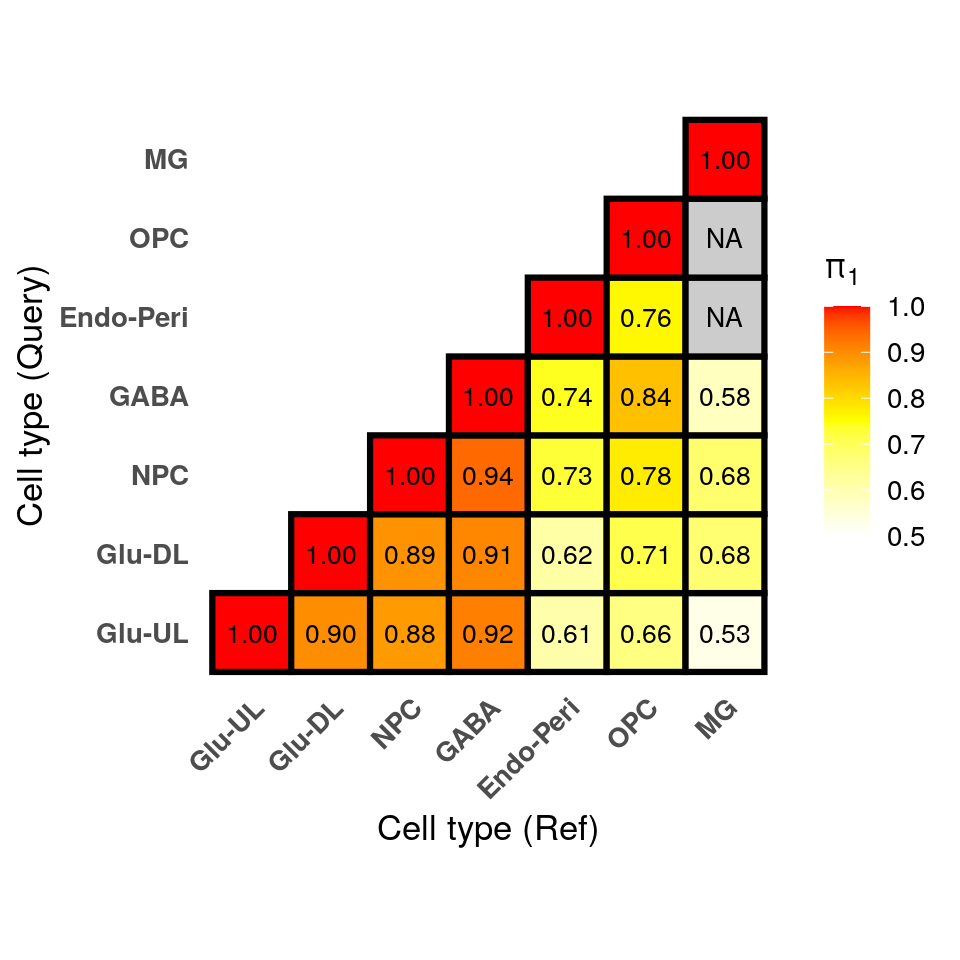

### Fugita

#### Table

Table 6. Fugita Pi1 Enrichment Summary cell-specific eQTL

| Cell Type | Reference Cell Type | Forward Test pi1 | Forward Test Prop. Replicating | Forward Test Prop. Same Dir. | Forward Test Overlap Count | Reference Test pi1 | Reference Test Prop. Replicating | Reference Test Prop. Same Dir. | Reference Test Overlap Count |
| --- | --- | --- | --- | --- | --- | --- | --- | --- | --- |
| Glu-UL | Ast | 0.68 | 0.66 | 0.95 | 198 | 0.61 | 0.47 | 0.94 | 60350 |
| Glu-DL | Ast | 0.81 | 0.78 | 0.92 | 119 | 0.51 | 0.39 | 0.95 | 61602 |
| GABA | Ast | 0.90 | 0.93 | 0.91 | 106 | 0.58 | 0.40 | 0.96 | 62287 |
| NPC | Ast | NA | NA | NA | 109 | 0.61 | 0.43 | 0.97 | 62056 |
| MG | Ast | NA | NA | NA | 12 | 0.36 | 0.14 | 0.97 | 62818 |
| OPC | Ast | NA | NA | NA | 23 | 0.40 | 0.17 | 0.99 | 62818 |
| Endo-Peri | Ast | NA | NA | NA | 13 | 0.36 | 0.15 | 0.99 | 62818 |
| Glu-UL | Exc | 0.61 | 0.77 | 0.94 | 137 | 0.37 | 0.28 | 0.92 | 105464 |
| Glu-DL | Exc | 0.73 | 0.85 | 0.93 | 95 | 0.40 | 0.25 | 0.93 | 109342 |
| GABA | Exc | 0.66 | 0.82 | 0.94 | 84 | 0.38 | 0.24 | 0.92 | 110291 |
| NPC | Exc | 0.84 | 0.87 | 0.85 | 78 | 0.35 | 0.20 | 0.91 | 109664 |
| MG | Exc | NA | NA | NA | 9 | 0.16 | 0.05 | 0.92 | 111588 |
| OPC | Exc | NA | NA | NA | 17 | 0.28 | 0.08 | 0.89 | 111588 |
| Endo-Peri | Exc | NA | NA | NA | 11 | 0.20 | 0.05 | 0.91 | 111588 |
| Glu-UL | Inh | 0.70 | 0.76 | 0.93 | 307 | 0.63 | 0.52 | 0.95 | 109563 |
| Glu-DL | Inh | 0.68 | 0.80 | 0.95 | 191 | 0.57 | 0.46 | 0.96 | 110632 |
| GABA | Inh | NA | NA | NA | 170 | 0.58 | 0.47 | 0.97 | 111032 |
| NPC | Inh | NA | NA | NA | 152 | 0.58 | 0.41 | 0.95 | 110676 |
| MG | Inh | NA | NA | NA | 15 | 0.36 | 0.11 | 0.97 | 111880 |
| OPC | Inh | NA | NA | NA | 24 | 0.39 | 0.16 | 0.93 | 111880 |
| Endo-Peri | Inh | NA | NA | NA | 16 | 0.36 | 0.15 | 0.97 | 111880 |
| Glu-UL | Oli | 0.75 | 0.71 | 0.91 | 92 | 0.54 | 0.35 | 0.94 | 28997 |
| Glu-DL | Oli | 0.65 | 0.80 | 0.86 | 61 | 0.23 | 0.27 | 0.96 | 30272 |
| GABA | Oli | 0.76 | 0.81 | 0.91 | 53 | 0.34 | 0.26 | 0.97 | 30911 |
| NPC | Oli | NA | NA | NA | 53 | 0.43 | 0.28 | 0.96 | 30865 |
| MG | Oli | NA | NA | NA | 6 | 0.04 | 0.10 | 0.98 | 31510 |
| OPC | Oli | NA | NA | NA | 11 | 0.48 | 0.11 | 0.98 | 31510 |
| Endo-Peri | Oli | NA | NA | NA | 8 | 0.29 | 0.10 | 0.99 | 31510 |
| Glu-UL | OPC | 0.60 | 0.55 | 0.92 | 582 | 0.67 | 0.57 | 0.93 | 76440 |
| Glu-DL | OPC | 0.58 | 0.65 | 0.92 | 333 | 0.59 | 0.46 | 0.94 | 76249 |
| GABA | OPC | 0.81 | 0.77 | 0.97 | 301 | 0.61 | 0.48 | 0.95 | 76671 |
| NPC | OPC | 0.85 | 0.88 | 0.94 | 282 | 0.61 | 0.53 | 0.94 | 76647 |
| MG | OPC | NA | NA | NA | 17 | 0.47 | 0.22 | 0.96 | 76989 |
| OPC | OPC | NA | NA | NA | 30 | 0.55 | 0.32 | 0.97 | 76989 |
| Endo-Peri | OPC | NA | NA | NA | 24 | 0.45 | 0.20 | 0.98 | 76989 |
| Glu-UL | Mic | 0.63 | 0.48 | 0.89 | 589 | 0.51 | 0.42 | 0.85 | 62954 |
| Glu-DL | Mic | 0.55 | 0.54 | 0.90 | 319 | 0.49 | 0.33 | 0.86 | 63793 |
| GABA | Mic | 0.72 | 0.63 | 0.94 | 300 | 0.41 | 0.32 | 0.91 | 63893 |
| NPC | Mic | 0.68 | 0.65 | 0.91 | 269 | 0.47 | 0.36 | 0.86 | 63860 |
| MG | Mic | NA | NA | NA | 20 | 0.35 | 0.21 | 0.99 | 64071 |
| OPC | Mic | NA | NA | NA | 24 | 0.31 | 0.18 | 0.94 | 64071 |
| Endo-Peri | Mic | NA | NA | NA | 29 | 0.35 | 0.20 | 0.94 | 64071 |
| Glu-UL | End | 0.49 | 0.17 | 0.85 | 162 | 0.64 | 0.49 | 0.92 | 5895 |
| Glu-DL | End | 0.50 | 0.18 | 0.80 | 85 | 0.43 | 0.47 | 0.81 | 5895 |
| GABA | End | 0.38 | 0.18 | 0.92 | 72 | 0.40 | 0.42 | 0.92 | 5928 |
| NPC | End | 0.49 | 0.18 | 0.77 | 73 | 0.36 | 0.43 | 0.94 | 5928 |
| MG | End | NA | NA | NA | 4 | 0.51 | 0.39 | 0.95 | 5928 |
| OPC | End | NA | NA | NA | 9 | 0.37 | 0.35 | 0.97 | 5928 |
| Endo-Peri | End | NA | NA | NA | 6 | 0.61 | 0.55 | 0.99 | 5928 |

#### Heatmap

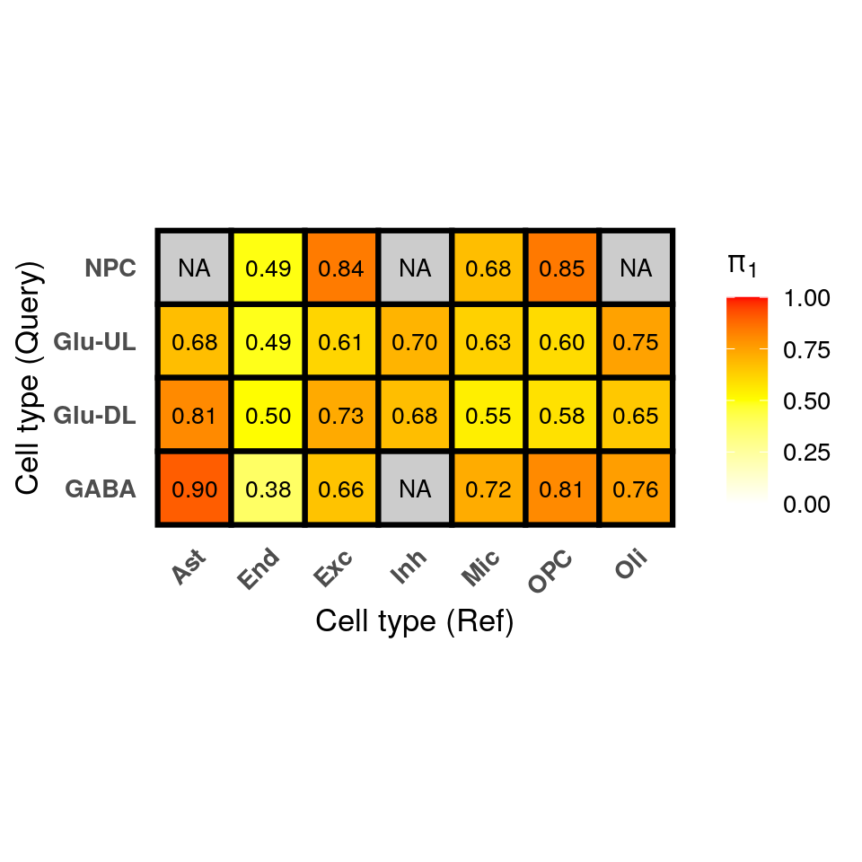

### Beta correlation

#### All

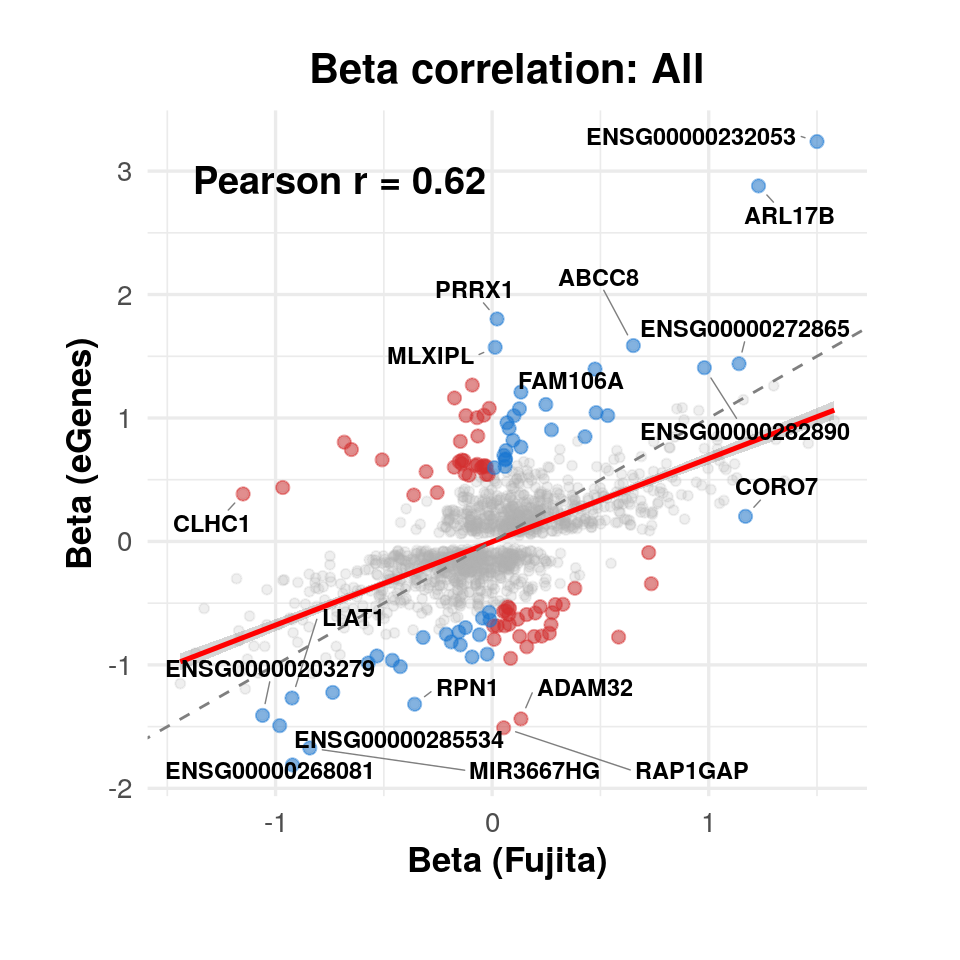

#### GABA

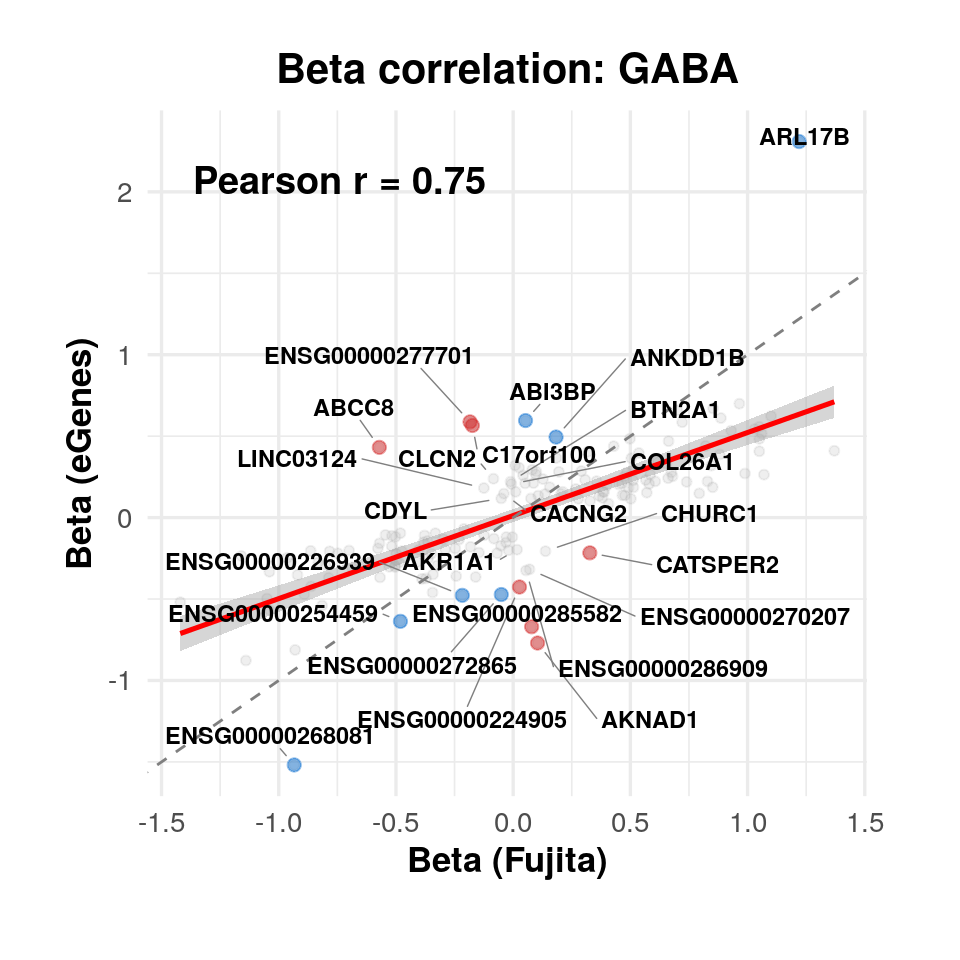

#### Glu-DL

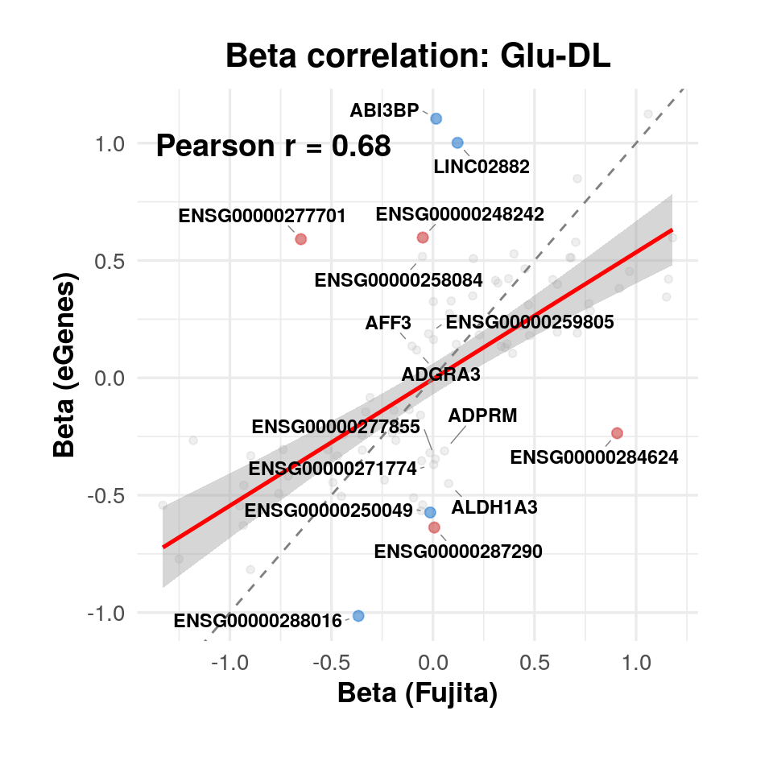

#### Glu-UL

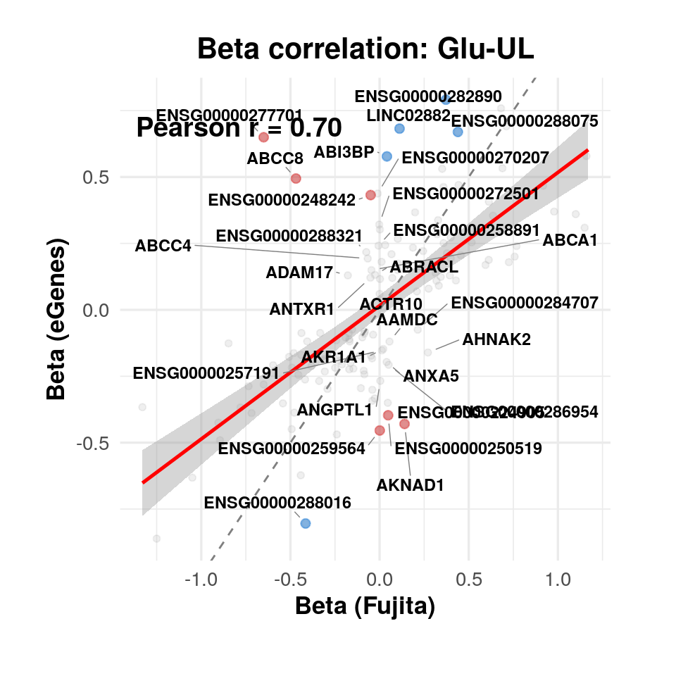

### Benchmarking

#### Table

Table 5. Benchmarking

Means and SD across replicates

| Rule | N | Mean Runtime (min) | SD Runtime (min) | Mean RAM (GB) | SD RAM (GB) |
| --- | --- | --- | --- | --- | --- |
| atac | 98 | 11.28 | 6.15 | 3.42 | 0.98 |
| cat | 34 | 10.32 | 0.46 | 4.79 | 0.41 |
| dwnld | 3 | 33.95 | 52.83 | 4.97 | 8.59 |
| pi1 | 1010 | 3.28 | 5.17 | 9.21 | 3.44 |
| snp | 98 | 0.62 | 0.77 | 0.48 | 0.18 |

#### Plot

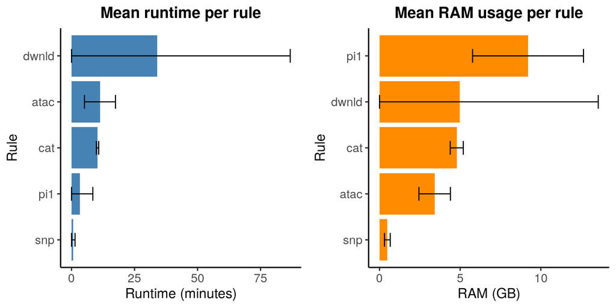